# LEGO-spreadsheet

Rick O. Gilmore

2019-02-25 14:24:25

# 1 Purpose

This document summarizes the quality assurance (QA) process conducted on the LEGO project session/participant metadata spreadsheet. The data are stored and shared at https://nyu.databrary.org/volume/563.

# 2 Set-up

```r
knitr::opts_chunk$set(echo = TRUE)

# Load databraryapi package from github.com/PLAY-behaviorome/databraryapi
if (!require(databraryapi)) {
  devtools::install_github("PLAY-behaviorome/databraryapi")
  library(databraryapi)
}
```

```
## Welcome to the databraryapi package
```

```r
# Load other libraries
library(tidyverse)
```

```r
library(ggplot2)

## Variables for this particular volume and session.
play_vol_id <- 563
#survey_data_session_name = "Parent report data"
```

The Databrary volume is 563.

We need to log in to Databrary to have access to these data. If you have logged-in before from the machine you are running this report, then you will be prompted to enter your Databrary ID (email address). If you have *not* logged-in before, you will be prompted to enter your Databrary ID (email address) and your Databrary password.

You may wish to knit (update) this report from the RStudio command line using this command: `rmarkdown::render('LEGO-spreadsheet.Rmd', params=list(db_account="youremail@yourdomain.com"))`, where `youremail@yourdomain.com` is your Databrary account ID.

```r
databraryapi::login_db(params$db_account)
```

```
## Login successful.
```

```
## [1] TRUE
```

# 3 Gather data

Participant demographic data are stored in the Databrary spreadsheet.

## 3.1 Participant demographics

We’ll first gather the participant demographic data stored in the Databrary spreadsheet.

```r
lego_demog_raw <- databraryapi::download_session_csv(vol_id = play_vol_id)

if (is.null(lego_demog_raw)) {
  stop("No data downloaded from Databrary. Are you logged in?")
}
```

### 3.1.1 Structure of demographic data file

```r
str(lego_demog_raw)
```

```
## 'data.frame':    74 obs. of  16 variables:
##  $ session_id            : int  24098 24099 24192 24362 24643 24658 24861 24964 24967 24968 ...
##  $ session_name          : Factor w/ 73 levels "LEGO_S#002_Visit1",..: 1 2 3 6 7 8 10 11 4 5 ...
##  $ session_date          : Factor w/ 73 levels "2017-12-11","2017-12-18",..: 1 2 3 6 8 7 10 11 4 5 ...
##  $ session_release       : Factor w/ 4 levels "","EXCERPTS",..: 3 3 2 2 2 2 2 2 2 2 ...
##  $ participant.ID        : int  2 2 3 5 5 6 7 7 4 4 ...
##  $ participant.birthdate : Factor w/ 36 levels "2016-02-11","2016-02-18",..: 14 14 1 19 19 2 3 3 18 18 ...
##  $ participant.gender    : Factor w/ 2 levels "Female","Male": 2 2 2 1 1 1 2 2 1 1 ...
##  $ participant.race      : Factor w/ 3 levels "More than one",..: 3 3 1 3 3 3 3 3 3 3 ...
##  $ participant.ethnicity : Factor w/ 2 levels "Hispanic or Latino",..: 2 2 2 2 2 2 2 2 2 2 ...
##  $ participant.disability: Factor w/ 2 levels "atypical","typical": 2 2 2 2 2 2 2 2 2 2 ...
##  $ participant.language  : Factor w/ 2 levels "English","English, Italian": 1 1 1 1 1 1 1 1 1 1 ...
##  $ group.name            : Factor w/ 4 levels "13 mos Crawler",..: 2 2 4 2 2 4 4 4 2 2 ...
##  $ context.setting       : Factor w/ 1 level "Home": 1 1 1 1 1 1 1 1 1 1 ...
##  $ context.language      : Factor w/ 1 level "English": 1 1 1 1 1 1 1 1 1 1 ...
##  $ context.country       : Factor w/ 1 level "US": 1 1 1 1 1 1 1 1 1 1 ...
##  $ context.state         : Factor w/ 1 level "NY": 1 1 1 1 1 1 1 1 1 1 ...
```

Let’s select all the variables and change the periods to underscores in the variable names.

```r
# Select relevant spreadsheet columns, filter those with actual session data, and rename variables to use underscores
lego_demog_raw <- lego_demog_raw %>%
  select(session_id,
         session_name,
         session_date,
         session_release,
         participant.ID,
         participant.birthdate,
         participant.gender,
         participant.race,
         participant.ethnicity,
         participant.disability,
         participant.language,
         group.name,
         context.setting,
         context.language,
         context.country,
         context.state) %>%
  # filter(session_release %in% c('EXCERPTS', 'PRIVATE', 'SHARED')) %>%
  rename(participant_ID = participant.ID,
         participant_birthdate = participant.birthdate,
         participant_gender = participant.gender,
         participant_race = participant.race,
         participant_ethnicity = participant.ethnicity,
         participant_disability = participant.disability,
         participant_language = participant.language,
         group_name = group.name,
         context_setting = context.setting,
         context_language = context.language,
         context_country = context.country,
         context.state = context.state)
```

# 4 QA tests for each variable

## 4.1 `session_name`

Are session name values consistent? Print sorted list to detect anomalies.

```r
lego_demog_raw %>%
  select(., session_name) %>%
  arrange(., session_name)
```

```
##         session_name
## 1  LEGO_S#002_Visit1
## 2  LEGO_S#002_Visit2
## 3  LEGO_S#003_Visit1
## 4  LEGO_S#004_Visit1
## 5  LEGO_S#004_Visit2
## 6  LEGO_S#005_Visit1
## 7  LEGO_S#005_Visit2
## 8  LEGO_S#006_Visit1
## 9  LEGO_S#006_Visit2
## 10 LEGO_S#007_Visit1
## 11 LEGO_S#007_Visit2
## 12 LEGO_S#008_Visit1
## 13 LEGO_S#008_Visit2
## 14 LEGO_S#009_Visit1
```

[output cut: 60 more lines]

## 4.2 `session_date`

Are `session_date` values valid `YYYY-MM-DD` dates? Use `lubridate` package to see if dates import properly.

```r
if (sum(is.na(lubridate::ymd(lego_demog_raw$session_date)))) {
  message("Some session_date values are invalid")
  is.na(lubridate::ymd(lego_demog_raw$session_date))
} else {
  message("All session_date values are valid.")
}
```

```
## All session_date values are valid.
```

Are `session_date` dates reasonable?

The earliest year is 2017.

The most recent year is 2019.

## 4.3 `session_release`

Are `session_release` values sensible? That is, are there ‘consistent’ permissions across the sessions or missing values?

```r
release_sum <- xtabs(formula = ~ participant_ID + session_release, lego_demog_raw)
knitr::kable(release_sum)
```

|  |  | EXCERPTS | PRIVATE | SHARED |
| --- | --- | --- | --- | --- |
| 2 | 0 | 0 | 2 | 0 |
| 3 | 0 | 1 | 0 | 0 |
| 4 | 0 | 2 | 0 | 0 |
| 5 | 0 | 2 | 0 | 0 |
| 6 | 0 | 1 | 0 | 1 |
| 7 | 0 | 2 | 0 | 0 |
| 8 | 0 | 1 | 0 | 1 |
| 9 | 0 | 0 | 0 | 2 |
| 10 | 0 | 2 | 0 | 0 |
| 11 | 0 | 2 | 0 | 0 |
| 12 | 0 | 2 | 0 | 0 |
| 13 | 0 | 2 | 0 | 0 |
| 14 | 0 | 1 | 1 | 0 |
| 15 | 0 | 2 | 0 | 0 |
| 16 | 0 | 0 | 0 | 2 |
| 17 | 0 | 0 | 2 | 0 |
| 18 | 0 | 0 | 0 | 2 |
| 19 | 0 | 2 | 0 | 0 |
| 20 | 0 | 0 | 2 | 0 |
| 21 | 0 | 0 | 1 | 1 |
| 22 | 0 | 2 | 0 | 0 |
| 23 | 0 | 1 | 1 | 0 |
| 24 | 0 | 0 | 2 | 0 |
| 25 | 0 | 2 | 0 | 0 |
| 26 | 0 | 2 | 0 | 0 |
| 27 | 0 | 0 | 0 | 1 |
| 28 | 0 | 0 | 2 | 0 |
| 29 | 0 | 0 | 1 | 1 |
| 30 | 0 | 0 | 1 | 1 |
| 31 | 0 | 2 | 0 | 0 |
| 32 | 0 | 2 | 0 | 0 |
| 33 | 0 | 2 | 0 | 0 |
| 34 | 0 | 2 | 0 | 0 |
| 35 | 1 | 0 | 0 | 1 |
| 36 | 0 | 1 | 0 | 1 |
| 37 | 0 | 0 | 0 | 3 |
| 40 | 0 | 0 | 1 | 0 |
| 41 | 0 | 2 | 0 | 0 |

### 4.3.1 Number of uploaded sessions per participant?

```r
lego_demog_raw %>%
  group_by(., participant_ID) %>%
  summarize(., n_sessions = n()) %>%
  knitr::kable(.)
```

| participant_ID | n_sessions |
| --- | --- |
| 2 | 2 |
| 3 | 1 |
| 4 | 2 |
| 5 | 2 |
| 6 | 2 |
| 7 | 2 |
| 8 | 2 |
| 9 | 2 |
| 10 | 2 |
| 11 | 2 |
| 12 | 2 |
| 13 | 2 |
| 14 | 2 |
| 15 | 2 |
| 16 | 2 |
| 17 | 2 |
| 18 | 2 |
| 19 | 2 |
| 20 | 2 |
| 21 | 2 |
| 22 | 2 |
| 23 | 2 |
| 24 | 2 |
| 25 | 2 |
| 26 | 2 |
| 27 | 1 |
| 28 | 2 |
| 29 | 2 |
| 30 | 2 |
| 31 | 2 |
| 32 | 2 |
| 33 | 2 |
| 34 | 2 |
| 35 | 2 |
| 36 | 2 |
| 37 | 3 |
| 40 | 1 |
| 41 | 2 |

The following participants have *fewer* than two sessions:

```r
lego_demog_raw %>%
  group_by(., participant_ID) %>%
  summarize(., n_sessions = n()) %>%
  filter(n_sessions < 2) %>%
  knitr::kable(.)
```

| participant_ID | n_sessions |
| --- | --- |
| 3 | 1 |
| 27 | 1 |
| 40 | 1 |

The following participants have *more* than two sessions:

```r
lego_demog_raw %>%
  group_by(., participant_ID) %>%
  summarize(., n_sessions = n()) %>%
  filter(n_sessions > 2) %>%
  knitr::kable(.)
```

| participant_ID | n_sessions |
| --- | --- |
| 37 | 3 |

## 4.4 `participant_birthdate`

### 4.4.1 Valid dates?

```r
if (sum(is.na(lubridate::ymd(lego_demog_raw$participant_birthdate)))) {
  message("Some participant_birthdate values are invalid")
  is.na(lubridate::ymd(lego_demog_raw$participant_birthdate))
} else {
  message("All session_date values are valid.")
}
```

```
## All session_date values are valid.
```

### 4.4.2 Dates give reasonable ages?

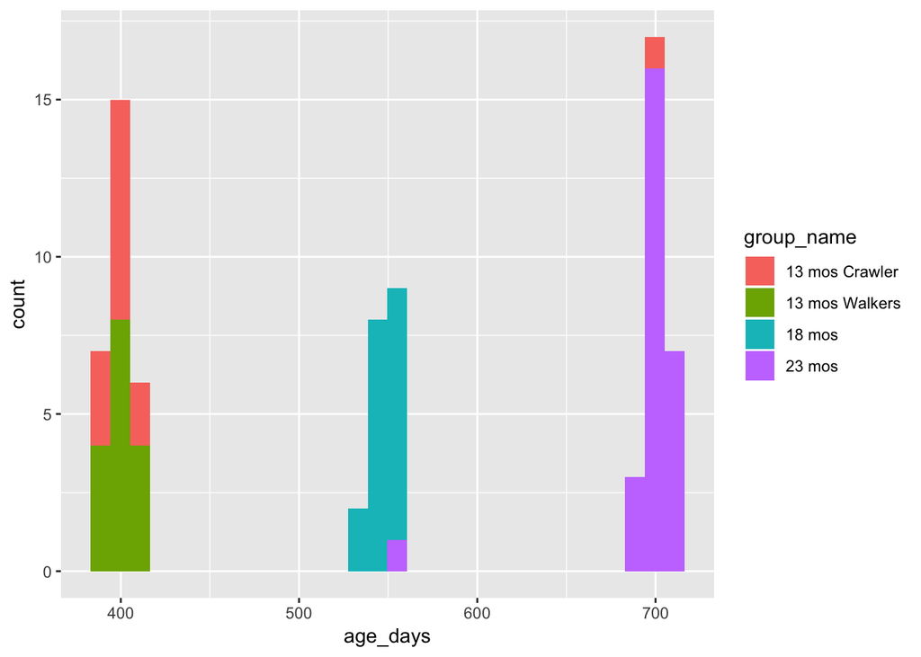

```r
birthdate <- lubridate::ymd(lego_demog_raw$participant_birthdate)
testdate <- lubridate::ymd(lego_demog_raw$session_date)
age_days <- testdate - birthdate

lego_demog_raw$age_days <- age_days
lego_demog_raw %>%
  ggplot(.) +
  aes(x = age_days, fill = group_name) +
  geom_histogram()
```

The histogram suggest that there is some mislabeling in the `group_name` variable given that there is a 13-mo-old crawler with an age ~700 days and a 23-mo-old with an age less than 600 days.

```r
lego_demog_raw %>%
  filter(., group_name == '13 mos Crawler', age_days > 500) %>%
  select(., participant_ID, session_name, session_id)
```

```
##   participant_ID      session_name session_id
## 1             37 LEGO_S#037_Visit1      33008
```

```r
lego_demog_raw %>%
  filter(., group_name == '23 mos', age_days < 600) %>%
  select(., participant_ID, session_name, session_id)
```

```
##   participant_ID      session_name session_id
## 1             33 LEGO_S#033_Visit2      32142
```

## 4.5 `particpant_gender`

### 4.5.1 Valid (‘Female’, ‘Male’) entry for all sessions?

```r
if (sum(!(lego_demog_raw$participant_gender %in% c('Female', 'Male')))) {
  message("Some participant_gender values are invalid.")
} else {
  message("All participant_gender values are valid.")
}
```

```
## All participant_gender values are valid.
```

### 4.5.2 Do `participant_gender` values match across sessions?

Generate variable for visit from `session_name` and while we’re there, grab the session number from `session_name`.

```r
lego_demog_raw <- lego_demog_raw %>%
  mutate(., visit = stringr::str_extract(session_name,
                                         "Visit[12]+"),
         sub_number = stringr::str_extract(session_name,
                                         "S#[0-9]+"))
lego_demog_raw %>%
  spread(., visit, participant_gender) %>%
  arrange(., participant_ID) %>%
  group_by(., participant_ID) %>%
  select(., participant_ID, sub_number, Visit1, Visit2) %>%
  knitr::kable(.)
```

| participant_ID | sub_number | Visit1 | Visit2 |
| --- | --- | --- | --- |
| 2 | S#002 | Male | NA |
| 2 | S#002 | NA | Male |
| 3 | S#003 | Male | NA |
| 4 | S#004 | Female | NA |
| 4 | S#004 | NA | Female |
| 5 | S#005 | Female | NA |
| 5 | S#005 | NA | Female |
| 6 | S#006 | Female | NA |
| 6 | S#006 | NA | Female |
| 7 | S#007 | Male | NA |
| 7 | S#007 | NA | Male |
| 8 | S#008 | Female | NA |
| 8 | S#008 | NA | Female |
| 9 | S#009 | Male | NA |
| 9 | S#009 | NA | Male |
| 10 | S#010 | Male | NA |
| 10 | S#010 | NA | Male |
| 11 | S#011 | Male | NA |
| 11 | S#011 | NA | Male |
| 12 | S#012 | Male | NA |
| 12 | S#012 | NA | Male |
| 13 | S#013 | Female | NA |
| 13 | S#013 | NA | Female |
| 14 | S#014 | Female | NA |
| 14 | S#014 | NA | Female |
| 15 | S#015 | Female | NA |
| 15 | S#015 | NA | Female |
| 16 | S#016 | Female | NA |
| 16 | S#016 | NA | Female |
| 17 | S#017 | Male | NA |
| 17 | S#017 | NA | Male |
| 18 | S#018 | Female | NA |
| 18 | S#018 | NA | Female |
| 19 | S#019 | Male | NA |
| 19 | S#019 | NA | Male |
| 20 | S#020 | Male | NA |
| 20 | S#020 | NA | Male |
| 21 | S#021 | Female | NA |
| 21 | S#021 | NA | Female |
| 22 | S#022 | Male | NA |
| 22 | S#022 | NA | Male |
| 23 | S#023 | Male | NA |
| 23 | S#023 | NA | Male |
| 24 | S#024 | Male | NA |
| 24 | S#024 | NA | Male |
| 25 | S#025 | Male | NA |
| 25 | S#025 | NA | Male |
| 26 | S#026 | Male | NA |
| 26 | S#026 | NA | Male |
| 27 | S#027 | Female | NA |
| 28 | S#028 | Female | NA |
| 28 | S#028 | NA | Female |
| 29 | S#029 | Male | NA |
| 29 | S#029 | NA | Male |
| 30 | S#030 | Female | NA |
| 30 | S#030 | NA | Female |
| 31 | S#031 | Female | NA |
| 31 | S#031 | NA | Female |
| 32 | S#032 | Male | NA |
| 32 | S#032 | NA | Male |
| 33 | S#033 | Female | NA |
| 33 | S#033 | NA | Female |
| 34 | S#034 | Male | NA |
| 34 | S#034 | NA | Male |
| 35 | S#035 | Male | NA |
| 35 | S#035 | NA | Male |
| 36 | S#036 | Male | NA |
| 36 | S#036 | NA | Male |
| 37 | S#037 | Female | NA |
| 37 | S#037 | NA | Female |
| 37 | S#037 | Female | NA |
| 40 | S#040 | Male | NA |
| 41 | S#041 | Female | NA |
| 41 | S#041 | NA | Female |